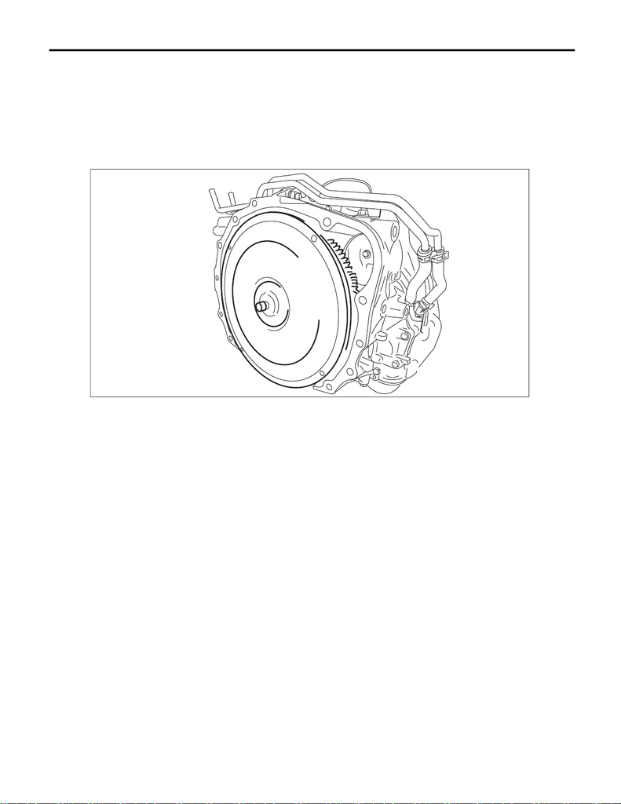

CVT(TR690)-140

Torque Converter Assembly

CONTINUOUSLY VARIABLE TRANSMISSION

27.Torque Converter Assembly

A: REMOVAL

Transmission Assembly.>

2) Pull out the torque converter assembly horizontally.

CAUTION:

Do not scratch the inside of engaging parts.

3) Remove the O-ring from the front reduction drive gear.

AT-07656

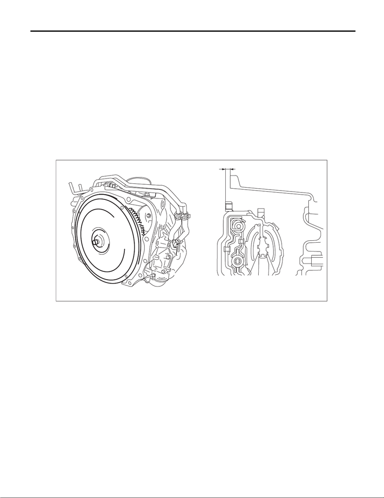

CVT(TR690)-141

Torque Converter Assembly

CONTINUOUSLY VARIABLE TRANSMISSION

B: INSTALLATION

1) Install the O-ring to front reduction drive gear.

NOTE:

• Use new O-rings.

• Apply CVTF to the O-ring.

2) While holding the torque converter assembly by hand, carefully install it into the torque converter case.

NOTE:

• Apply CVTF to the oil seal lip.

• Do not damage the oil seal and O-ring.

assembly.

4) Measure depth “A”, from converter case end surface to drive plate contacting surface.

Standard (reference):

6.8 mm (0.268 in) or less

Transmission Assembly.>

C: INSPECTION

• Check the protrusion of torque converter center (front boss) is not deformed or damaged.

• Check the ring gear and exterior for break or damage.

AT-07657

A